# QHCI 2021 - Project 2

Group 4

24.05.2021

# Introduction

This project is based on the paper *[How We Type: Movement Strategies and Performance in Everyday Typing](https://dl.acm.org/doi/10.1145/2858036.2858233)*. We used the data set the authors have provided within the course of their study. The aim of the data analysis will be to answer the following to research questions (*RQ*):

- *RQ1: Do overall typing speed differ between touch-typist and non-touchtypist?*
- *RQ2: How much does the result from RQ1 influenced by whether the participants type known-words or random string?*

The analysis will base on the **within-subject design** (with repeated trials) of the study including **one independent variable *(IV)*** that has **three levels**. The **IV *stimulus tpye*** refers to the type of string users had to type in for the transcription and has three levels:

- *sentences*: easy regular sentences
- *random*: random sequences of letters
- *mix*: a mix of the two other conditions

For the experiments they used a **randomized order** for the three *stimulus types*.

### Theoretical Background

The Feit (2006) paper compares typing of self-taught typists (or everyday typists or non-touch typists) to touch typists (those that took a typing course and are trained on ten-finger touch typing system). It does not seem to be the case that everyday typists are inferior in their typing skills/performance.

They conducted three types of tasks: easy sentences of commonly used words (sentences), random letter strings (random) and a mix of those two (mix). Thirty typists participated. They captured key press data (keyboard logging), motion capture data (the position of each finger at and between keystrokes) and eye tracking/attention data (with eye-tracking glasses). The experiment followed a within-subject design.

The paper does not find a significant difference in words-per-minute (*wpm*) performance between touch typists (57.8 *wpm*) and non-touch typists (58.93 *wpm*). Touch typists and non-touch typists seem to have comparable speed. When typing random letter sequences the paper finds that entry rate dropped on average by around 50% compared to the sentences condition. The change was similar across both groups, with no significant difference between their performances in the random condition.

# Data Analysis

Within this part we will analyze the data set and try to answer the two research questions.

## Setup

Before we can jump into the analysis we start by installing the required packages.

```r
# define packages
packages <- c("tidyverse","lme4","multcomp","broom.mixed","lmerTest","ggplot2","plyr","lsm","lsmeans","car","stringr","qqplotr", "moments")

# install packages when they are not already included
install.packages(setdiff(packages, rownames(installed.packages())))
```

To finish the setup we need to load the packages fo finish the setup.

```r
# load the packages
library(tidyverse)
library(lme4)
library(ggplot2)
library(broom.mixed)
library(lmerTest)
library(lsm)
library(lsmeans)
library(car)
library(stringr)
import::from(moments, skewness)
import::from(MASS,mvrnorm)
import::from(broom.mixed,tidy)
import::from(multcomp, glht, mcp, adjusted)
import::from(qqplotr, stat_qq_line, stat_qq_point, stat_qq_band)
import::from(modelr, add_residuals, add_predictions)
import::from(car, leveneTest)
import::from(plyr, ddply)
```

## Data Processing

Next we can start with the data processing. First off, we define a helper function `readLog` which takes a file path and parses the filename and data of the file.

```r
# Regular expression to help parse the log files
regex_parse <- "User(\\d+)_T(\\d+)_(.*).csv"
# helper function to read in log files
readLog <- function(fileName) {
    csv_data <- read_csv(str_c('./log/',fileName)) %>%
      mutate(length = str_length(stimulus)) %>%
      group_by(stimulus_index) %>%
      summarise(wpm = (as.double(max(length)-1)/5)/ as.double(max(input_time_ms)) * 60000, length = max(length)) %>%
      mutate(user_id = factor(str_replace(fileName, regex_parse, "\\1")), condition = str_replace(fileName, regex_parse, "\\3"))
    return(csv_data)
}
```

Thereafter, we define all the existing log files (`log_files`) and and the csv containing the participant information (`participant_info`).

```r
# list of all log files
log_files <- list.files('./log')
# file that includes the participant information
participant_info <- read_csv("participant_info.csv")
```

Now we are ready to process the log files and create the data we need.

```r
# map over all files in the log folder and parse the data
data <- as_tibble_col(lapply(log_files, readLog), col='nested') %>%
        unnest(nested) %>% merge(y=participant_info, by='user_id', all.x = TRUE ) %>%
        mutate(typing_style = if_else(is_touchtypist, 'Touchtypist', 'Non-touchtypist')) %>%
        select(-is_touchtypist, -length) %>%
        mutate(condition = factor(condition, levels = c("Sentences", "Mix", "Random")), typing_style = factor(typing_style, levels = c("Non-touchtypist", "Touchtypist")))
```

> Note that the *IV stimulus type* is now referred to as *condition* in our data set with the same three levels (*Sentences, Random, Mix*). The *typing style* will still be referred to as *typing style*.

## Data Exploration and Description

After having processed the data, we now want to inspect and explore it to get a better overview. To do so we can describe its basic properties.

### General Information

Thus, it is a good idea to have a quick look at the data by using `head(data)`.

|  | user_id | stimulus_index | wpm | condition | typing_style |
| --- | --- | --- | --- | --- | --- |
| 1 | 106194 | 0 | 34.83089 | Sentences | Non-touchtypist |
| 2 | 106194 | 1 | 48.59939 | Sentences | Non-touchtypist |
| 3 | 106194 | 2 | 48.87551 | Sentences | Non-touchtypist |
| 4 | 106194 | 3 | 75.51622 | Sentences | Non-touchtypist |
| 5 | 106194 | 4 | 54.03974 | Sentences | Non-touchtypist |
| 6 | 106194 | 5 | 43.79562 | Sentences | Non-touchtypist |

Next we check the structure of the data object with `str(data)` and can see the data types of each column.

```
## 'data.frame':    4493 obs. of  5 variables:
##  $ user_id       : Factor w/ 30 levels "106194","120778",..: 1 1 1 1 1 1 1 1 1 1 ...
##  $ stimulus_index: num  0 1 2 3 4 5 6 7 8 9 ...
##  $ wpm           : num  34.8 48.6 48.9 75.5 54 ...
##  $ condition     : Factor w/ 3 levels "Sentences","Mix",..: 1 1 1 1 1 1 1 1 1 1 ...
##  $ typing_style  : Factor w/ 2 levels "Non-touchtypist",..: 1 1 1 1 1 1 1 1 1 1 ...
```

Our data set contains 5 columns (*user_id, stimulus_index, wpm, condition, typing_style*) and 4493 rows for 30 different users.

### Descriptive Statistics

Now that we know how the data looks and what type of data it contains, we can have a look at the data itself. To get a broad overview of the data we use the `summary` function.

```
##     user_id     stimulus_index      wpm              condition
##  106194 : 150   Min.   : 0.0   Min.   :  6.389   Sentences:1499
##  120778 : 150   1st Qu.:12.0   1st Qu.: 29.197   Mix      :1497
##  173269 : 150   Median :24.0   Median : 40.495   Random   :1497
##  216367 : 150   Mean   :24.5   Mean   : 43.432
##  221357 : 150   3rd Qu.:37.0   3rd Qu.: 56.112
##  250694 : 150   Max.   :49.0   Max.   :109.331
##  (Other):3593
##           typing_style
##  Non-touchtypist:2396
##  Touchtypist    :2097
##
##
##
##
##
```

In order to answer the research questions we will now have a look at the *wpm* first with regards to the *typing style* (RQ1) and then in connection with the different *conditions* (RQ2). To support this process we will also create suitable visualizations for the data sets.

#### **RQ1 - words per minute by typing styles**

First we create a violin plot that includes boxplots for *wpm* by the *typing styles* of users.

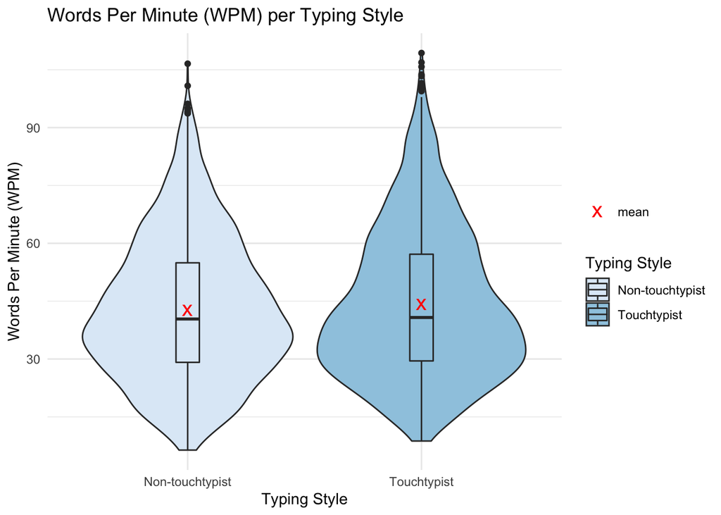

Out of this first visualization, we can already imply that there is no big difference between the two *typing styles* with regards to *wpm*. This is also shown in the numbers below.

**Non-Parametric Statisctics**

- Median:
  - On the one hand Non-touchtypist has a `median` of 40.3754218 *wpm* and on the other hand Touchtypist has a `median` of 40.7680945 *wpm*.
- Min and Max Values:
  - For the `min` values Non-touchtypist has a value of 6.3890959 *wpm* and Touchtypist has a value of 8.7412587 *wpm*.
  - Regarding the `max`values Non-touchtypist has a value of 106.5614208 *wpm* and Touchtypist has a value of 109.33082 *wpm*.
- Interquartile Range (IQR) :
  - The `IQR` of Non-touchtypist amounts to 25.7998562 and the `IQR` for Touchtypist to 27.6594083.

These non-parametric statistical properties confirm the initial impressions from the visualization above that there are only slight differences between the two *typing styles* with regards to *wpm*. The `median`, `min`, `max`, as well as the `IQR` reveal only small differences.

**Parametric Statistics**

- Mean:
  - On the one hand Non-touchtypist has a `mean` of 42.715547 *wpm* and on the other hand Touchtypist has a `mean` of 44.2501875 *wpm*.
- Spread:
  - For the variance (`var`), Non-touchtypist has a value of 338.9006071 and Touchtypist has a value of 375.0135804.
  - Regarding the standard deviation, (`sd`) Non-touchtypist accounts to 18.4092533 and Touchtypist to 19.3652674.

These numbers shows that also the parametric statistical properties in the form of `mean`, variance(`var`) and standard deviation(`sd`) are quite similar.

Now that we have concrete numbers for both the `mean` and the `median` for *typing styles* by *wpm* we can make a statement about the distributions of the data and their shapes. For Non-touchtypist that have a `mean` of 42.715547 *wpm* and a `median` of 40.3754218 *wpm*, the shape is skewed-right. The same applies for Touchtypist that have a `mean` of 44.2501875 *wpm* and a `median` of 40.7680945 *wpm*, where the shape is skewed-right as well.

Both shapes are only slightly skewed as can also be seen in the visualization where the `mean` and `median` are very close. Eventually, the numbers confirmed the initial impressions from the visualizations that there is not a big difference between the two *typing styles* with regards to the *wpm*.

#### **RQ2 - words per minute by typing style and condition (stimulus type)**

We begin by taking a look at condition on its own. We create the same plot again for *wpm* by the different *conditions*.

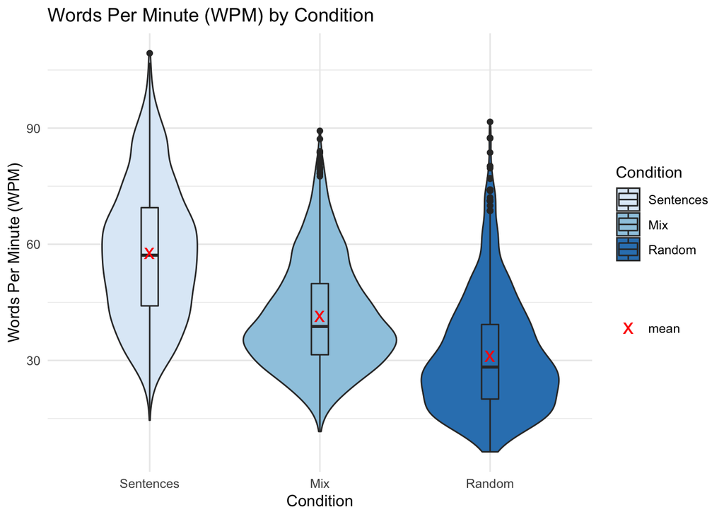

In contrast to the visualization before, in this case we immediately see that the violin and boxplots appear to be quite different with regards to the *conditions* and *wpm*. We see that random characters/words seem to lead to the lowest *wpm* performance, while known sentences show the highest *wpm* performance. The mix condition, as to be expected, lies between the two conditions, random and sentences. Next, we can take a look at the numbers.

**Non-Parametric Statistics**

- Median:
  - Sentences has a `median` of 57.167605 *wpm*, Mix has a `median` of 38.7625792 *wpm* and Random has a `median` of 28.2885431 *wpm*.
- Min and Max Values:
  - For the `min` values Sentences has a value of 14.5406477 *wpm*, Mix has a value of 11.6360502 *wpm* and Random has a value of 6.3890959 *wpm*.
  - Regarding the `max`values Sentences has a value of 109.33082 *wpm*, Mix has a value of 89.2789012 *wpm* and Random has a value of 91.6030534 *wpm*.
- Interquartile Range (IQR) :
  - The `IQR` of Sentences amounts to 25.3715642, the `IQR` for Mix to 18.3630421 and the `IQR` for Random to 19.2403134.

The `median`, `min`, `max`, as well as the `IQR` this time show significant differences that are also obvious in the visualizations. Upon these we can already make a statement about RQ2.

At this point we can already say that there are obvious differences between the *conditions*.

**Parametric Statistics**

- Mean:
  - For the Sentences users have a `mean` of 57.7361984 *wpm*, for Mix a `mean` of 41.4473594 *wpm* and for Random has a `mean` of 31.0927423 *wpm*.
- Spread:
  - For the variance (`var`), Sentences has a value of 303.6272773, Mix has a value of 187.2133526 and Random has a value of 217.1712564.
  - Regarding the standard deviation, (`sd`) Sentences accounts to 17.4249039, Mix to 13.682593 and Random to 14.7367315.

- Condition Sentences:
  - Sentences have a `mean` of 57.7361984 *wpm* and a `median` of 57.167605 *wpm*.
- Condition Mix:
  - Mix has a `mean` of 41.4473594 *wpm* and a `median` of 38.7625792 *wpm*.
- Condition Random:
  - Random has a `mean` of 31.0927423 *wpm* and a `median` of 28.2885431 *wpm*.

After looking at *condition* on its own, we turn to the interaction of *typing style* and *condition*. We create the violin plot for *wpm* by the different *typing styles* and *conditions*. We find that even across *conditions* there do not seem to be significant differences between non-touchtypists and touchtypists in *wpm*. These findings all seem to support the Feit (2006) paper.

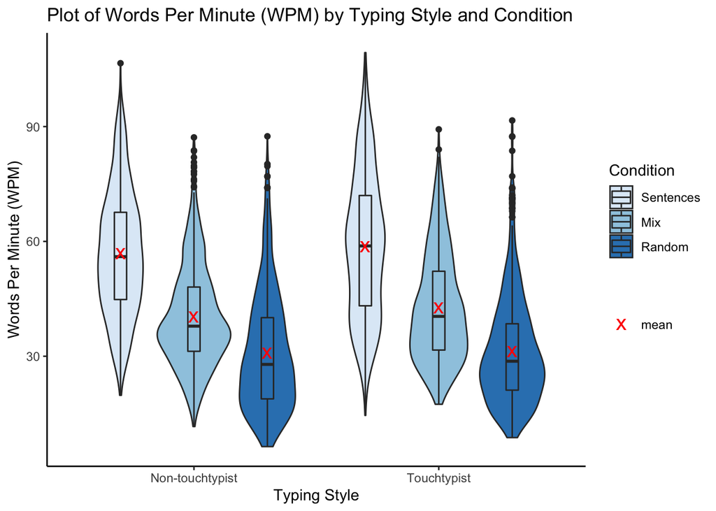

Again, let’s have a look at the numbers:

| typing_style | condition | Min. | 1st Qu. | Median | Mean | 3rd Qu. | Max. |
| --- | --- | --- | --- | --- | --- | --- | --- |
| Non-touchtypist | Sentences | 19.799646 | 44.81444 | 56.02241 | 56.85066 | 67.60050 | 106.56142 |
| Non-touchtypist | Mix | 11.636050 | 31.28900 | 37.86118 | 40.37437 | 48.08028 | 87.17949 |
| Non-touchtypist | Random | 6.389096 | 18.86199 | 27.86809 | 30.90683 | 40.08016 | 87.46356 |
| Touchtypist | Sentences | 14.540648 | 43.18019 | 58.81966 | 58.74698 | 71.99564 | 109.33082 |
| Touchtypist | Mix | 17.454545 | 31.61159 | 40.41377 | 42.67560 | 52.20005 | 89.27890 |
| Touchtypist | Random | 8.741259 | 21.14165 | 28.69440 | 31.30499 | 38.48621 | 91.60305 |

Finally, we can create a line plot. The line plot confirms the observation that there is very little difference between touchtypists and non-touchtypists across *conditions*.

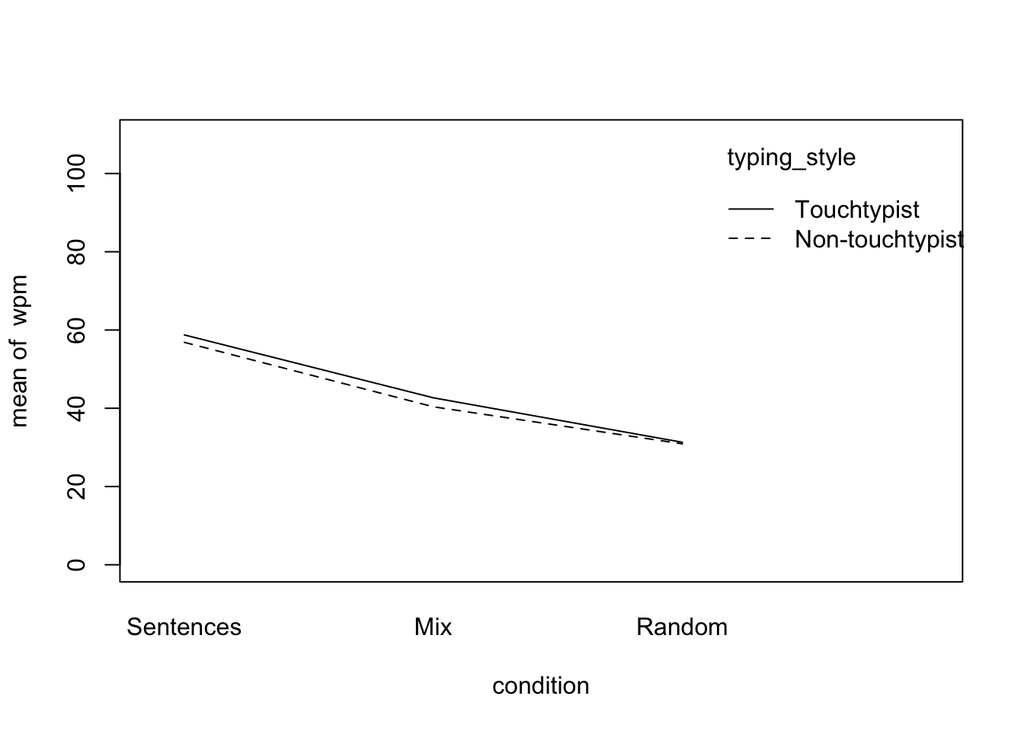

## Modelling and Testing Assumptions

After exploring and visualizing the data, we can first set up our model and then take a look at it. We will set up a linear mixed model. In our case, we have multiple users. The variable `typing_style` is a between subjects variable and the variable `condition` is a within subjects variable. Furthermore, we have multiple trials, whereby the variable is called `stimulus_index.` We are trying to predict words per minute.

```r
# setting up the model
model <- lmer(wpm ~ (typing_style*condition)/stimulus_index+(1|user_id),data=data)
```

We now test the statistical assumptions of the model. For this, we run the shapiro-wilk normality test and the levene test to check the homoscedasticity assumption. We expect high p-values which represent a non-violation.

```r
# shapiro-wilkinson test
shapiro.test(residuals(model))
```

```
##
##  Shapiro-Wilk normality test
##
## data:  residuals(model)
## W = 0.99615, p-value = 2.029e-09
```

```r
# levene test
leveneTest(residuals(model) ~ data$typing_style, center = "median")
```

|  | Df | F value | Pr(>F) |
| --- | --- | --- | --- |
| group | 1 | 0.1691905 | 0.6808519 |
|  | 4491 | NA | NA |

For the Levene test we find that we do not reject the homoscedasticity assumption. For the Shapiro test, the p-value is extremely small and therefore the test reports a violation. Since our data set is rather large, and the shapiro-wilk test is prone to report false-negatives with large data sets, we further explore the normality of residuals with different charts. In the QQ-Plot, we find a slight deviation from the QQ-Band at around at value of 25. However, because the sample size is very large, we can also see, that the QQ-Band is rather narrow.

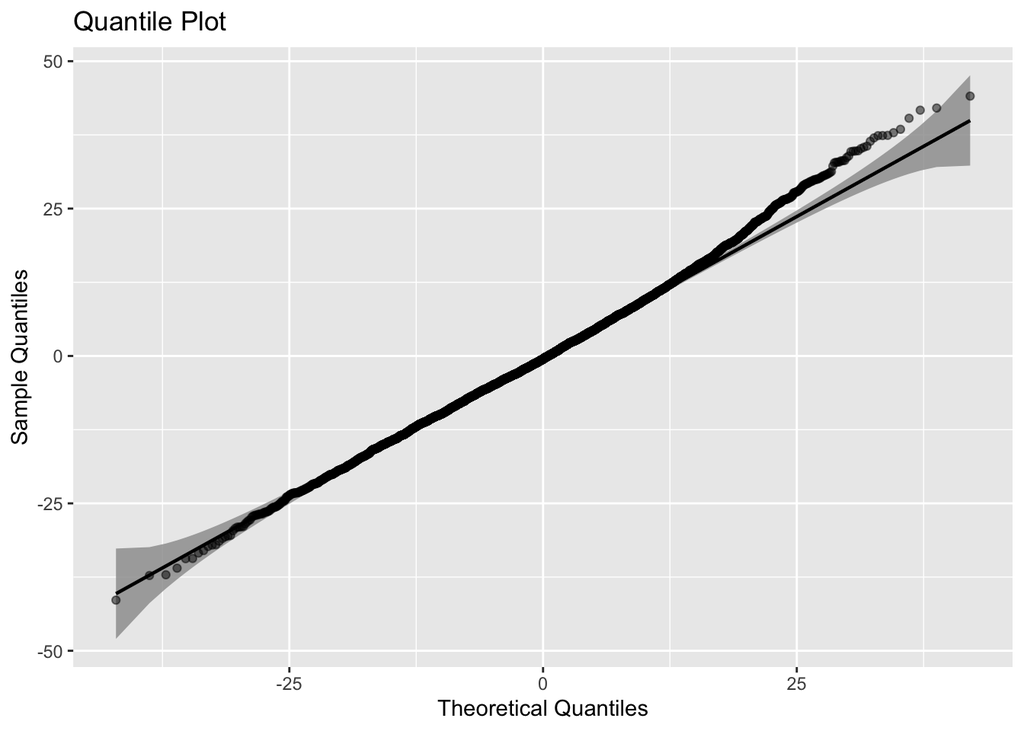

If we have a look at the histogram of the residuals, we can see the slight skewness at about a value of 25 as well. Overall, the distribution of residuals is still very close to a normal distribution.

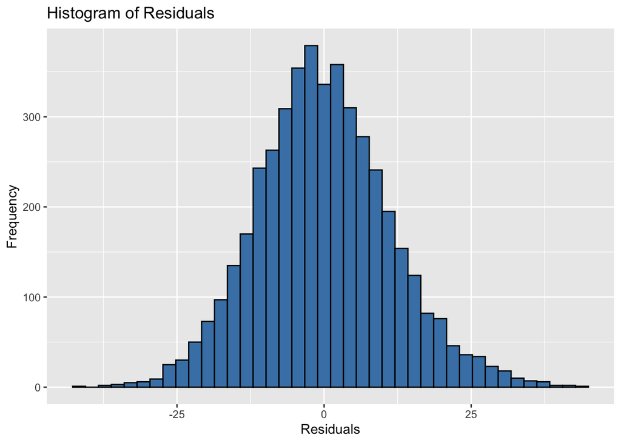

Nonetheless, we can explore how a log transformation affects the histogram and the QQ-Plot of residuals. We find that the transformation violates the normality assumption more than the non-transformed model. Therefore, we stick with our initial model.

```r
# log transformation of the model
model_log <- lmer(log(wpm) ~ (typing_style*condition)/stimulus_index+(1|user_id),data=data)
```

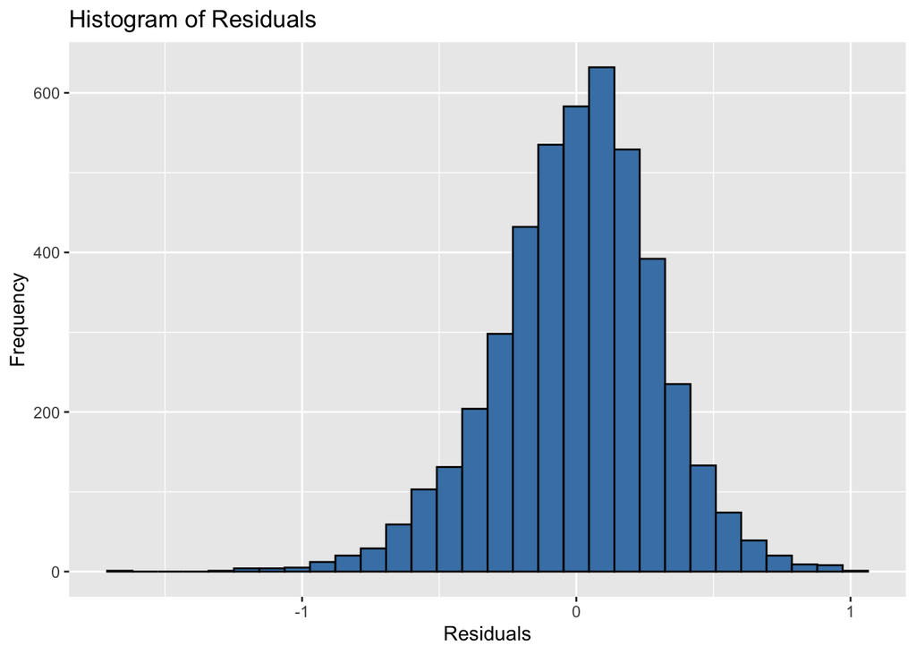

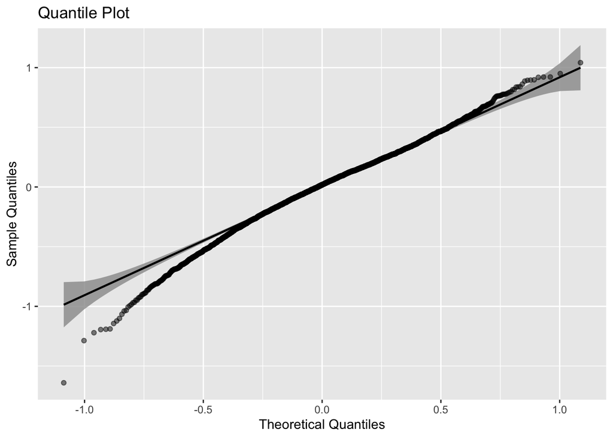

## Interpretation of the Results

What we find in the model, is that the effect on *typing style* is not significant and neither is the effect on the interaction term *typing style* * *condition*. The *condition* itself however does show a significant effect.

> Mixed models have much larger degrees of freedom.

```r
# analyze with anova
anova(model,type=3,test.statistic="F")
```

|  | Sum Sq | Mean Sq | NumDF | DenDF | F value | Pr(>F) |
| --- | --- | --- | --- | --- | --- | --- |
| typing_style | 34.44326 | 34.44326 | 1 | 29.27133 | 0.2627403 | 6.120903e-01 |
| condition | 133813.66181 | 66906.83090 | 2 | 4453.00038 | 510.3790147 | 2.706115e-200 |
| typing_style:condition | 147.10583 | 73.55291 | 2 | 4453.00038 | 0.5610767 | 5.706347e-01 |
| typing_style:condition:stimulus_index | 1687.86161 | 281.31027 | 6 | 4453.00058 | 2.1458924 | 4.527137e-02 |

We can create a model summary which shows the model formula and breaks down the fixed and random effects. The p-values show again that there is no significant difference between touchtypists and non-touchtypists and that it does not change across *conditions*.

```
## Linear mixed model fit by REML. t-tests use Satterthwaite's method [
## lmerModLmerTest]
## Formula: wpm ~ (typing_style * condition)/stimulus_index + (1 | user_id)
##    Data: data
##
## REML criterion at convergence: 34812.8
##
## Scaled residuals:
##     Min      1Q  Median      3Q     Max
## -3.6166 -0.6567 -0.0484  0.6242  3.8495
##
## Random effects:
##  Groups   Name        Variance Std.Dev.
##  user_id  (Intercept) 111.4    10.55
##  Residual             131.1    11.45
## Number of obs: 4493, groups:  user_id, 30
##
## Fixed effects:
##                                                                 Estimate
## (Intercept)                                                    5.747e+01
## typing_styleTouchtypist                                        2.182e+00
## conditionMix                                                  -1.765e+01
## conditionRandom                                               -2.533e+01
## typing_styleTouchtypist:conditionMix                           6.028e-01
## typing_styleTouchtypist:conditionRandom                       -1.121e+00
## typing_styleNon-touchtypist:conditionSentences:stimulus_index -2.575e-02
## typing_styleTouchtypist:conditionSentences:stimulus_index     -3.696e-02
## typing_styleNon-touchtypist:conditionMix:stimulus_index        2.200e-02
## typing_styleTouchtypist:conditionMix:stimulus_index            3.766e-03
## typing_styleNon-touchtypist:conditionRandom:stimulus_index    -5.103e-02
## typing_styleTouchtypist:conditionRandom:stimulus_index        -7.702e-02
##                                                               Std. Error
## (Intercept)                                                    2.757e+00
## typing_styleTouchtypist                                        4.035e+00
## conditionMix                                                   1.129e+00
## conditionRandom                                                1.129e+00
## typing_styleTouchtypist:conditionMix                           1.652e+00
## typing_styleTouchtypist:conditionRandom                        1.652e+00
## typing_styleNon-touchtypist:conditionSentences:stimulus_index  2.806e-02
## typing_styleTouchtypist:conditionSentences:stimulus_index      2.999e-02
```

[output cut: 56 more lines]

```
## typng_T:M:_  0.000  0.000  0.000  0.000 -0.445  0.000  0.000  0.000  0.000
## typn_N-:R:_  0.000  0.000  0.000 -0.609  0.000  0.416  0.000  0.000  0.000
## typng_T:R:_  0.000  0.000  0.000  0.000  0.000 -0.445  0.000  0.000  0.000
##             t_T:M: t_N-:R
## typng_stylT
## conditionMx
## conditnRndm
## typng_stT:M
## typng_stT:R
## typn_N-:S:_
## typng_T:S:_
## typn_N-:M:_
## typng_T:M:_
## typn_N-:R:_  0.000
## typng_T:R:_  0.000  0.000
```

To check the null-hypothesis we can take a look at the confidence intervals. Since the value 0 is contained in the 95% confidence interval of *typing style*, we cannot reject the null-hypothesis that touchtypists and non-touchtypists are the same across conditions in terms of *wpm*.

```
##                                                                      2.5 %
## .sig01                                                          8.05125251
## .sigma                                                         11.20350813
## (Intercept)                                                    52.09043219
## typing_styleTouchtypist                                        -5.69233059
## conditionMix                                                  -19.85679437
## conditionRandom                                               -27.54200987
## typing_styleTouchtypist:conditionMix                           -2.63170600
## typing_styleTouchtypist:conditionRandom                        -4.35558065
## typing_styleNon-touchtypist:conditionSentences:stimulus_index  -0.08069216
## typing_styleTouchtypist:conditionSentences:stimulus_index      -0.09568512
## typing_styleNon-touchtypist:conditionMix:stimulus_index        -0.03294190
## typing_styleTouchtypist:conditionMix:stimulus_index            -0.05497860
## typing_styleNon-touchtypist:conditionRandom:stimulus_index     -0.10595824
## typing_styleTouchtypist:conditionRandom:stimulus_index         -0.13583527
##                                                                      97.5 %
## .sig01                                                         13.460833971
## .sigma                                                         11.678149477
## (Intercept)                                                    62.849780810
## typing_styleTouchtypist                                        10.057255410
## conditionMix                                                  -15.436291013
## conditionRandom                                               -23.122369684
## typing_styleTouchtypist:conditionMix                            3.837317561
## typing_styleTouchtypist:conditionRandom                         2.113302430
## typing_styleNon-touchtypist:conditionSentences:stimulus_index   0.029196868
## typing_styleTouchtypist:conditionSentences:stimulus_index       0.021759128
## typing_styleNon-touchtypist:conditionMix:stimulus_index         0.076935823
## typing_styleTouchtypist:conditionMix:stimulus_index             0.062510531
## typing_styleNon-touchtypist:conditionRandom:stimulus_index      0.003907607
## typing_styleTouchtypist:conditionRandom:stimulus_index         -0.018202934
```

Furthermore, the General Linear Hypothesis Test (GLHT) also shows that there is no significant difference between touchtypists and non touchtypists by giving similar p-values and confidence intervals as above.

| term | contrast | null.value | estimate | conf.low | conf.high | statistic | adj.p.value |
| --- | --- | --- | --- | --- | --- | --- | --- |
| typing_style | Touchtypist - Non-touchtypist | 0 | 2.182452 | -5.725994 | 10.0909 | 0.540881 | 0.5885896 |

Finally we create a summary that tests every linear hypothesis for the *conditions* and *typing styles*. Not only do we find that there is no significant difference in *wpm* between non-touchtypists and touchtypists, we also find that this does not change when looking at random strings and sentences. Neither `"Non-touchtypist Random" - "Touchtypist Random" == 0` nor `"Non-touchtypist Sentences" - "Touchtypist Sentences" == 0` turn out to be significant.

```
##
##   Simultaneous Tests for General Linear Hypotheses
##
## Fit: lmer(formula = wpm ~ (typing_style * condition)/stimulus_index +
##     (1 | user_id), data = data)
##
## Linear Hypotheses:
##                                                             Estimate
## (Non-touchtypist Sentences) - Touchtypist Sentences == 0     -1.9077
## (Non-touchtypist Sentences) - (Non-touchtypist Mix) == 0     16.4770
## (Non-touchtypist Sentences) - Touchtypist Mix == 0           14.1383
## (Non-touchtypist Sentences) - (Non-touchtypist Random) == 0  25.9514
## (Non-touchtypist Sentences) - Touchtypist Random == 0        25.5268
## Touchtypist Sentences - (Non-touchtypist Mix) == 0           18.3847
## Touchtypist Sentences - Touchtypist Mix == 0                 16.0460
## Touchtypist Sentences - (Non-touchtypist Random) == 0        27.8591
## Touchtypist Sentences - Touchtypist Random == 0              27.4345
## (Non-touchtypist Mix) - Touchtypist Mix == 0                 -2.3387
## (Non-touchtypist Mix) - (Non-touchtypist Random) == 0         9.4744
## (Non-touchtypist Mix) - Touchtypist Random == 0               9.0498
## Touchtypist Mix - (Non-touchtypist Random) == 0              11.8131
## Touchtypist Mix - Touchtypist Random == 0                    11.3885
## (Non-touchtypist Random) - Touchtypist Random == 0           -0.4246
##                                                             Std. Error
## (Non-touchtypist Sentences) - Touchtypist Sentences == 0        3.9075
## (Non-touchtypist Sentences) - (Non-touchtypist Mix) == 0        0.5728
## (Non-touchtypist Sentences) - Touchtypist Mix == 0              3.9075
## (Non-touchtypist Sentences) - (Non-touchtypist Random) == 0     0.5730
## (Non-touchtypist Sentences) - Touchtypist Random == 0           3.9075
## Touchtypist Sentences - (Non-touchtypist Mix) == 0              3.9075
## Touchtypist Sentences - Touchtypist Mix == 0                    0.6124
## Touchtypist Sentences - (Non-touchtypist Random) == 0           3.9075
## Touchtypist Sentences - Touchtypist Random == 0                 0.6122
## (Non-touchtypist Mix) - Touchtypist Mix == 0                    3.9075
## (Non-touchtypist Mix) - (Non-touchtypist Random) == 0           0.5730
## (Non-touchtypist Mix) - Touchtypist Random == 0                 3.9075
## Touchtypist Mix - (Non-touchtypist Random) == 0                 3.9076
## Touchtypist Mix - Touchtypist Random == 0                       0.6127
## (Non-touchtypist Random) - Touchtypist Random == 0              3.9075
##                                                             t value
```

[output cut: 19 more lines]

```
## (Non-touchtypist Sentences) - (Non-touchtypist Random) == 0  < 0.001 ***
## (Non-touchtypist Sentences) - Touchtypist Random == 0        < 0.001 ***
## Touchtypist Sentences - (Non-touchtypist Mix) == 0           < 0.001 ***
## Touchtypist Sentences - Touchtypist Mix == 0                 < 0.001 ***
## Touchtypist Sentences - (Non-touchtypist Random) == 0        < 0.001 ***
## Touchtypist Sentences - Touchtypist Random == 0              < 0.001 ***
## (Non-touchtypist Mix) - Touchtypist Mix == 0                 0.98674
## (Non-touchtypist Mix) - (Non-touchtypist Random) == 0        < 0.001 ***
## (Non-touchtypist Mix) - Touchtypist Random == 0              0.13241
## Touchtypist Mix - (Non-touchtypist Random) == 0              0.01869 *
## Touchtypist Mix - Touchtypist Random == 0                    < 0.001 ***
## (Non-touchtypist Random) - Touchtypist Random == 0           1.00000
## ---
## Signif. codes:  0 '***' 0.001 '**' 0.01 '*' 0.05 '.' 0.1 ' ' 1
## (Adjusted p values reported -- single-step method)
```

# Conclusion

After exploring and analyzing our data, we have not seen a significant effect on word per minute for different *typing styles* (RQ1). Moreover, after looking at *condition* * *typing style*, a significant difference could not be found, which was confirmed by the model (RQ2). Still, it has to be noted that the *condition* itself shows a significant effect on the resulting *wpm.* Both findings (RQ1, RQ2) were not suprising after looking at the descriptive statistics and visualizations.